# Generative AI in Risk and Finance

#### Build the graph

Finally, we build the graph and add all nodes and edges defined above.

```python
from langgraph.graph import START, END, StateGraph

builder = StateGraph(OverallState)
builder.add_node("extract_topic", extract_topic_node)
builder.add_node("off_topic_response", off_topic_response_node)
builder.add_node("extract_companies", extract_companies_node)
builder.add_node("rag_agent", rag_agent_node)
builder.add_node("count_context", count_context_node)
builder.add_node("web_agent", web_agent_node)
builder.add_node("generate_answer", generate_answer_node)
builder.add_edge(START, "extract_topic")
builder.add_conditional_edges("extract_topic", general_router, {
    "on-topic": "extract_companies", "off-topic": "off_topic_response"})
builder.add_conditional_edges("extract_companies", rag_router, {
    "map-reduce": "rag_agent"})
builder.add_edge("rag_agent", "count_context")
builder.add_conditional_edges("count_context", web_router, {
    "relevant-context-found": "generate_answer",
    "relevant-context-not-found": "web_agent"})
builder.add_edge("web_agent", "generate_answer")
builder.add_edge("generate_answer", END)
builder.add_edge("off_topic_response", END)
graph = builder.compile()
```

Displaying the graph gives you a visual representation of the flow of the agent.

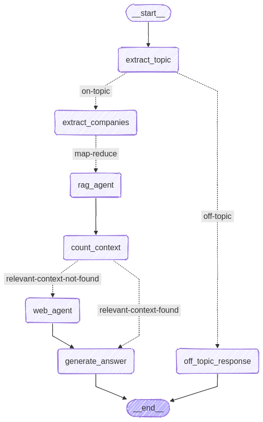

```python
from IPython.display import Image, display

display(Image(graph.get_graph(xray=1).draw_mermaid_png(
    frontmatter_config={
        "config": {
            "layout": "dagre",
            "look": "handDrawn"}}
    )))
```

We can now stream the graph to propagate the user query through the graph-based agent in oder to generate a final answer.

```python
from util import print_graph_propagation
```

```python
# Off-topic query
query = "How is the weather in New York?"

print_graph_propagation(graph, query)
```

```
User query: How is the weather in New York?

-----------------

Graph events:
1. Node: extract_topic
    State: topic
        Content: dax_40_related=False topic='' ...
2. Node: off_topic_response
    State: final_answer
        Content: Your query is not concerned about DAX 40 companies
    and therefore off topic within the context of this agent. ...

-----------------

Answer: Your query is not concerned about DAX 40 companies
    and therefore off topic within the context of this agent. ...
```

```python
# Query with specific DAX 40 companies
query = "What are the climate-related risks for Adidas and BMW?"

print_graph_propagation(graph, query)
```

```
User query: What are the climate-related risks for Adidas and BMW?

-----------------

Graph events:
1. Node: extract_topic
    State: topic
        Content: dax_40_related=True topic='climate-related risks' ...
2. Node: extract_companies
    State: companies
        Content: [Company(name='adidas'), Company(name='bmw')] ...
3. Node: rag_agent
    State: context_report
        Content: [Document(id='07512924-8d4b-40ef-b846-9dfa66092443', metadata={'company': 'adidas', 'year': 2023}, page_content='Climate scenario analysis confirmed our previous findings that the overall global green ...
4. Node: rag_agent
    State: context_report
        Content: [Document(id='98eaf969-33dd-4ac8-b975-662454b3b3ca', metadata={'company': 'bmw', 'year': 2023}, page_content='Moreover, oth er \noverarching topics are monitored by means of regular media \nanalysis.  ...
5. Node: count_context
    State: context_count
        Content: 3 ...
6. Node: generate_answer
    State: final_answer
        Content: Adidas and BMW, both DAX 40 companies, face climate-related risks that are categorized using the Task Force on Climate-Related Financial Disclosures (TCFD) framework. For Adidas, the primary concern i ...

-----------------

Answer: Adidas and BMW, both DAX 40 companies, face climate-related risks that are categorized using the Task Force on Climate-Related Financial Disclosures (TCFD) framework. For Adidas, the primary concern i ...
```

```python
# DAX 40 related query but without mentioning any specific company
query = "Which risks do corporations face due to climate change?"

print_graph_propagation(graph, query)
```

```
User query: Which risks do corporations face due to climate change?

-----------------

Graph events:
1. Node: extract_topic
    State: topic
        Content: dax_40_related=True topic='risks due to climate change' ...
2. Node: extract_companies
    State: companies
        Content: None ...
3. Node: rag_agent
    State: context_report
        Content: [] ...
4. Node: rag_agent
    State: context_report
        Content: [] ...
5. Node: rag_agent
    State: context_report
        Content: [] ...
6. Node: rag_agent
    State: context_report
        Content: [] ...
7. Node: rag_agent
    State: context_report
        Content: [] ...
8. Node: rag_agent
    State: context_report
        Content: [] ...
9. Node: rag_agent
    State: context_report
        Content: [] ...
10. Node: rag_agent
    State: context_report
        Content: [] ...
11. Node: rag_agent
    State: context_report
        Content: [] ...
12. Node: rag_agent
    State: context_report
```

[output cut: 83 more lines]

```
    State: context_report
        Content: [Document(id='4c22ee62-360d-43bb-a296-b47e2bae3afe', metadata={'company': 'vonovia', 'year': 2023}, page_content='We have assessed the corre-\nsponding ”risk of business continuity in disasters/crisis ...
41. Node: rag_agent
    State: context_report
        Content: [Document(id='8c7f4a5f-f314-4844-bd8c-8a695ba4dc37', metadata={'company': 'commerzbank', 'year': 2023}, page_content='As a major financier of the German economy, we are also active \nin sectors that a ...
42. Node: count_context
    State: context_count
        Content: 16 ...
43. Node: generate_answer
    State: final_answer
        Content: Corporations face several risks due to climate change, which can be categorized into physical and transition risks. Physical risks include acute and chronic impacts such as extreme weather events, ris ...

-----------------

Answer: Corporations face several risks due to climate change, which can be categorized into physical and transition risks. Physical risks include acute and chronic impacts such as extreme weather events, ris ...
```

### Deployment

**LangGraph Studio** significantly **enhances the deployment of AI agents** by providing a comprehensive development environment tailored for LangGraph applications. It **allows developers to visualize, interact with, and debug agent workflows**, enabling the creation of scalable, production-ready AI agents with features like stateful computation, long-term memory, and human-in-the-loop capabilities.

```python
!cd studio && langgraph dev
```

Wait for LangSmith opening automatically in your default browser.

[figure not shown]